# Project 5: Show of Hands

Tim Hagemeister

07 November, 2019

# The Data

The dataset for this lab (download here) contains the responses from 3,906 American users of the “Show of Hands” app for iPhone and Android. On the app, users answer questions about a variety of socioeconomic questions ranging from gender, income, and political party to more esoteric questions like “Does life have a purpose?” or “Are you left-handed?”. For this lab, you may assume that this dataset represents our entire population in question.

# The Lab

Your goal is to study the distribution of political affiliation for a category that you’re interested in. Available options for this lab are: Income, Household Status, or Education Level. You may pick any one of these three to study.

- Make a sample for each level of your category of interest (about 6).
- Construct and intepret 50% CIs, 95% CIs, and 99% CIs for political affiliation for each sample. Check to see which ones worked.
- Present your results in a polished report.

```r
# Filter The Data
BachelorDegree <- PolData %>% filter(EducationLevel == "Bachelor's Degree" )
HighSchool <- PolData %>% filter(EducationLevel == "High School Diploma" )
K12 <- PolData %>% filter(EducationLevel == "Current K-12" )
CurrentUndergraduate <- PolData %>% filter(EducationLevel == "Current Undergraduate" )
MasterDegree <- PolData %>% filter(EducationLevel == "Master's Degree" )
AssociateDegree <- PolData %>% filter(EducationLevel == "Associate's Degree" )
DoctoralDegree <- PolData %>% filter(EducationLevel == "Doctoral Degree" )
```

```r
# Take Samples

BachelorDegreeSample <- sample(BachelorDegree$Party, 50)
HighSchoolSample <- sample(HighSchool$Party, 50)
K12Sample <- sample(K12$Party, 50)
CurrentUndergraduateSample <- sample(CurrentUndergraduate$Party, 50)
MasterDegreeSample <- sample(MasterDegree$Party, 50)
AssociateDegreeSample <- sample(AssociateDegree$Party, 50)
DoctoralDegreeSample <- sample(DoctoralDegree$Party, 50)
```

```r
# Sample Proportion
phat_BachelorDegree <-sum(BachelorDegreeSample == "Democrat")/50
phat_HighSchool <-sum(HighSchoolSample == "Democrat")/50
phat_K12 <-sum(K12Sample == "Democrat")/50
phat_CurrentUndergraduate <-sum(CurrentUndergraduateSample == "Democrat")/50
phat_MasterDegree <-sum(MasterDegreeSample == "Democrat")/50
phat_AssociateDegree <-sum(AssociateDegreeSample == "Democrat")/50
phat_DoctoralDegree <-sum(DoctoralDegreeSample == "Democrat")/50
```

```r
# True Proportions
prop_BachelorDegree <- sum(BachelorDegree == "Democrat")/nrow(BachelorDegree)
prop_HighSchool <- sum(HighSchool == "Democrat")/nrow(HighSchool)
prop_K12 <- sum(K12 == "Democrat")/nrow(K12)
prop_CurrentUndergraduate <- sum(CurrentUndergraduate == "Democrat")/nrow(CurrentUndergraduate)
prop_MasterDegree <- sum(MasterDegree == "Democrat")/nrow(MasterDegree)
prop_AssociateDegree <- sum(AssociateDegree == "Democrat")/nrow(AssociateDegree)
prop_DoctoralDegree <- sum(DoctoralDegree == "Democrat")/nrow(DoctoralDegree)
```

```r
## BachelorDegree
###lower50BachelorDegree
lower50BachelorDegree <- phat_BachelorDegree - 0.67449*sqrt(phat_BachelorDegree*(1-phat_BachelorDegree)/50)
##upper5BachelorDegree
upper50BachelorDegree <- phat_BachelorDegree + 0.67449*sqrt(phat_BachelorDegree*(1-phat_BachelorDegree)/50)
###lower95BachelorDegree
lower95BachelorDegree <- phat_BachelorDegree - 1.96*sqrt(phat_BachelorDegree*(1-phat_BachelorDegree)/50)
###upper95BachelorDegree
upper95BachelorDegree <- phat_BachelorDegree + 1.96*sqrt(phat_BachelorDegree*(1-phat_BachelorDegree)/50)
###lower99BachelorDegree
lower99BachelorDegree <- phat_BachelorDegree - 2.576*sqrt(phat_BachelorDegree*(1-phat_BachelorDegree)/50)
##upper99BachelorDegree
upper99BachelorDegree <- phat_BachelorDegree + 2.576*sqrt(phat_BachelorDegree*(1-phat_BachelorDegree)/50)


BachelorDegreeCI50 <- c("Bachelor Degree", round(lower50BachelorDegree,3), round(upper50BachelorDegree,3), round(prop_BachelorDegree, 3))

BachelorDegreeCI95 <- c("Bachelor Degree", round(lower95BachelorDegree,3), round(upper95BachelorDegree,3), round(prop_BachelorDegree, 3))

BachelorDegreeCI99 <- c("Bachelor Degree", round(lower99BachelorDegree,3), round(upper99BachelorDegree,3), round(prop_BachelorDegree, 3))
```

```r
## Highschool
###lower50
lower50HighSchool <- phat_HighSchool - 0.67449*sqrt(phat_HighSchool*(1-phat_HighSchool)/50)
##upper50
upper50HighSchool <- phat_HighSchool + 0.67449*sqrt(phat_HighSchool*(1-phat_HighSchool)/50)
###lower95
lower95HighSchool <- phat_HighSchool - 1.96*sqrt(phat_HighSchool*(1-phat_HighSchool)/50)
###upper95
upper95HighSchool <- phat_HighSchool + 1.96*sqrt(phat_HighSchool*(1-phat_HighSchool)/50)
###lower99
lower99HighSchool <- phat_HighSchool - 2.576*sqrt(phat_HighSchool*(1-phat_HighSchool)/50)
##upper99
upper99HighSchool <- phat_HighSchool + 2.576*sqrt(phat_HighSchool*(1-phat_HighSchool)/50)

HighSchoolCI50 <- c("High School", round(lower50HighSchool,3), round(upper50HighSchool,3), round(prop_HighSchool, 3))

HighSchoolCI95 <- c("High School", round(lower95HighSchool,3), round(upper95HighSchool,3), round(prop_HighSchool, 3))

HighSchoolCI99 <- c("High School", round(lower99HighSchool,3), round(upper99HighSchool,3), round(prop_HighSchool, 3))
```

```r
## phat_K12
###lower50
lower50K12 <- phat_K12 - 0.67449*sqrt(phat_K12*(1-phat_K12)/50)
##upper50
upper50K12 <- phat_K12 + 0.67449*sqrt(phat_K12*(1-phat_K12)/50)
###lower95
lower95K12 <- phat_K12 - 1.96*sqrt(phat_K12*(1-phat_K12)/50)
###upper95
upper95K12 <- phat_K12 + 1.96*sqrt(phat_K12*(1-phat_K12)/50)
###lower99
lower99K12 <- phat_K12 - 2.576*sqrt(phat_K12*(1-phat_K12)/50)
##upper99
upper99K12 <- phat_K12 + 2.576*sqrt(phat_K12*(1-phat_K12)/50)

K12CI50 <- c("K-12 ", round(lower50K12,3) ,round(upper50K12,3), round(prop_K12, 3))

K12CI95 <- c("K-12 ", round(lower95K12,3),round(upper95K12,3), round(prop_K12, 3))

K12CI99 <- c("K-12 ", round(lower99K12,3) ,round(upper99K12,3), round(prop_K12, 3))
```

```r
## prop_CurrentUndergraduate
###lower50
lower50Undergraduate <- phat_CurrentUndergraduate - 0.67449*sqrt(phat_CurrentUndergraduate*(1-phat_CurrentUndergraduate)/50)
##upper50
upper50Undergraduate <- phat_CurrentUndergraduate + 0.67449*sqrt(phat_CurrentUndergraduate*(1-phat_CurrentUndergraduate)/50)
###lower95
lower95Undergraduate <- phat_CurrentUndergraduate - 1.96*sqrt(phat_CurrentUndergraduate*(1-phat_CurrentUndergraduate)/50)
###upper95
upper95Undergraduate <- phat_CurrentUndergraduate + 1.96*sqrt(phat_CurrentUndergraduate*(1-phat_CurrentUndergraduate)/50)
###lower99
lower99Undergraduate <- phat_CurrentUndergraduate - 2.576*sqrt(phat_CurrentUndergraduate*(1-phat_CurrentUndergraduate)/50)
##upper99
upper99Undergraduate <- phat_CurrentUndergraduate + 2.576*sqrt(phat_CurrentUndergraduate*(1-phat_CurrentUndergraduate)/50)

CurrentUndergraduateCI50 <- c("Current Undergraduate", round(lower50Undergraduate,3) , round(upper50Undergraduate,3), round(prop_CurrentUndergraduate, 3))

CurrentUndergraduateCI95 <- c("Current Undergraduate", round(lower95Undergraduate,3),round(upper95Undergraduate,3), round(prop_CurrentUndergraduate, 3))

CurrentUndergraduateCI99 <- c("Current Undergraduate", round(lower99Undergraduate,3) , round(upper99Undergraduate,3), round(prop_CurrentUndergraduate, 3))
```

```r
## prop_MasterDegree
###lower50
lower50Master <- phat_MasterDegree - 0.67449*sqrt(phat_MasterDegree*(1-phat_MasterDegree)/50)
##upper50
upper50Master <- phat_MasterDegree + 0.67449*sqrt(phat_MasterDegree*(1-phat_MasterDegree)/50)
###lower95
lower95Master <- phat_MasterDegree - 1.96*sqrt(phat_MasterDegree*(1-phat_MasterDegree)/50)
###upper95
upper95Master <- phat_MasterDegree + 1.96*sqrt(phat_MasterDegree*(1-phat_MasterDegree)/50)
###lower99
lower99Master <- phat_MasterDegree - 2.576*sqrt(phat_MasterDegree*(1-phat_MasterDegree)/50)
##upper99
upper99Master <- phat_MasterDegree + 2.576*sqrt(phat_MasterDegree*(1-phat_MasterDegree)/50)

MasterDegreeCI50 <- c("Master Degree",round( lower50Master,3),round(upper50Master,3), round(prop_MasterDegree, 3))

MasterDegreeCI95 <- c("Master Degree",round( lower95Master,3),round(upper95Master,3), round(prop_MasterDegree, 3))

MasterDegreeCI99 <-c("Master Degree", round(lower99Master,3),round(upper99Master,3), round(prop_MasterDegree, 3))
```

```r
## prop_AssociateDegree
###lower50
lower50Associate <- phat_AssociateDegree - 0.67449*sqrt(phat_AssociateDegree*(1-phat_AssociateDegree)/50)
###upper50
upper50Associate <- phat_AssociateDegree + 0.67449*sqrt(phat_AssociateDegree*(1-phat_AssociateDegree)/50)
###lower95
lower95Associate <- phat_AssociateDegree - 1.96*sqrt(phat_AssociateDegree*(1-phat_AssociateDegree)/50)
###upper95
upper95Associate <- phat_AssociateDegree + 1.96*sqrt(phat_AssociateDegree*(1-phat_AssociateDegree)/50)
###lower99
lower99Associate <- phat_AssociateDegree - 2.576*sqrt(phat_AssociateDegree*(1-phat_AssociateDegree)/50)
##upper99
upper99Associate <- phat_AssociateDegree + 2.576*sqrt(phat_AssociateDegree*(1-phat_AssociateDegree)/50)


AssociateDegreeCI50 <- c("AssociateDegree", round(lower50Associate,3),round(upper50Associate,3), round(prop_AssociateDegree, 3))

AssociateDegreeCI95 <- c("AssociateDegree", round(lower95Associate,3),round(upper95Associate,3), round(prop_AssociateDegree, 3))

AssociateDegreeCI99 <- c("AssociateDegree",round(lower99Associate,3),round(upper99Associate,3), round(prop_AssociateDegree, 3))
```

```r
## prop_DoctoralDegree
###lower50
lower50Doctoral <- phat_DoctoralDegree - 0.67449*sqrt(phat_DoctoralDegree*(1-phat_DoctoralDegree)/50)
###upper50
upper50Doctoral <- phat_DoctoralDegree + 0.67449*sqrt(phat_DoctoralDegree*(1-phat_DoctoralDegree)/50)
###lower95
lower95Doctoral <- phat_DoctoralDegree - 1.96*sqrt(phat_DoctoralDegree*(1-phat_DoctoralDegree)/50)
###upper95
upper95Doctoral <- phat_DoctoralDegree + 1.96*sqrt(phat_DoctoralDegree*(1-phat_DoctoralDegree)/50)
###lower99
lower99Doctoral <- phat_DoctoralDegree - 2.576*sqrt(phat_DoctoralDegree*(1-phat_DoctoralDegree)/50)
##upper99
upper99Doctoral <- phat_DoctoralDegree + 2.576*sqrt(phat_DoctoralDegree*(1-phat_DoctoralDegree)/50)

DoctoralDegreeCI50 <- c("Doctoral Degree", round(lower50Doctoral, 3),round(upper50Doctoral, 3), round(prop_DoctoralDegree, 3))

DoctoralDegreeCI95 <- c("Doctoral Degree", round(lower95Doctoral, 3),round(upper95Doctoral, 3), round(prop_DoctoralDegree, 3))

DoctoralDegreeCI99 <- c("Doctoral Degree", round(lower99Doctoral, 3),round(upper99Doctoral, 3), round(prop_DoctoralDegree, 3))
```

```r
levelCI50 <- t(cbind(BachelorDegreeCI50, HighSchoolCI50, K12CI50, CurrentUndergraduateCI50, MasterDegreeCI50, AssociateDegreeCI50, DoctoralDegreeCI50))

levelCI50 <- as.data.frame(levelCI50)
col_headings <- c("Education Level","50% CI lower", "50% CI upper",  "True Population Proportion")
names(levelCI50) <- col_headings

table50 <- ggtexttable(levelCI50, rows = NULL,
                        theme = ttheme("mGreen"))
```

```r
levelCI95 <- t(cbind(BachelorDegreeCI95, HighSchoolCI95, K12CI95, CurrentUndergraduateCI95, MasterDegreeCI95, AssociateDegreeCI95, DoctoralDegreeCI95))

levelCI95 <- as.data.frame(levelCI95)
col_headings <- c("Education Level","95% CI lower", "95% CI upper", "True Population Proportion")
names(levelCI95) <- col_headings

table95 <- ggtexttable(levelCI95, rows = NULL,
                        theme = ttheme("mRed"))
```

```r
levelCI99 <- t(cbind(BachelorDegreeCI99, HighSchoolCI99, K12CI99, CurrentUndergraduateCI99, MasterDegreeCI99, AssociateDegreeCI99, DoctoralDegreeCI99))

levelCI99 <- as.data.frame(levelCI99)
col_headings <- c("Education Level","99% CI lower", "99% CI upper", "True Population Proportion")
names(levelCI99) <- col_headings

table99 <- ggtexttable(levelCI99, rows = NULL,
                        theme = ttheme("mBlue"))
```

```r
chart50 <- ggplot()+
  geom_line(aes(x = c(lower50BachelorDegree ,upper50BachelorDegree), y = "Bachelor Degree"), color = "darkgreen")+
  geom_line(aes(x = c(lower50HighSchool ,upper50HighSchool), y = "High School"), color = "darkgreen")+
  geom_line(aes(x = c(lower50Undergraduate  ,upper50Undergraduate), y = "Current Undergraduate"), color = "darkgreen")+
  geom_line(aes(x = c(lower50Master ,upper50Master), y = "Master Degree"), color = "darkgreen")+
  geom_line(aes(x = c(lower50Associate ,upper50Associate), y = "Associat eDegree"), color = "darkgreen")+
  geom_line(aes(x = c(lower50Doctoral ,upper50Doctoral), y = "Doctoral Degree"), color = "darkgreen")+
  geom_line(aes(x = c(lower50K12 ,upper50K12), y = "K-12"), color = "darkgreen")+
  geom_point(aes(x = prop_BachelorDegree, y= "Bachelor Degree"), color = "red", size = 5)+
  geom_point(aes(x = prop_HighSchool, y= "High School"), color = "red", size = 5)+
  geom_point(aes(x = prop_CurrentUndergraduate, y= "Current Undergraduate"), color = "red", size = 5)+
  geom_point(aes(x = prop_MasterDegree, y= "Master Degree"), color = "red", size = 5)+
  geom_point(aes(x = prop_AssociateDegree, y= "Associat eDegree"), color = "red", size = 5)+
  geom_point(aes(x = prop_DoctoralDegree, y= "Doctoral Degree"), color = "red", size = 5)+
  geom_point(aes(x = prop_K12, y= "K-12"), color = "red", size = 5)+
  xlab("Confidance Interval Range")+
  ylab("Education Levels")+
  theme_minimal()
```

```r
chart95 <- ggplot()+
  geom_line(aes(x = c(lower95BachelorDegree ,upper95BachelorDegree), y = "Bachelor Degree"), color = "red")+
  geom_line(aes(x = c(lower95HighSchool ,upper95HighSchool), y = "High School"), color = "red")+
  geom_line(aes(x = c(lower95Undergraduate  ,upper95Undergraduate), y = "Current Undergraduate"), color = "red")+
  geom_line(aes(x = c(lower95Master ,upper95Master), y = "Master Degree"), color = "red")+
  geom_line(aes(x = c(lower95Associate ,upper95Associate), y = "Associat eDegree"), color = "red")+
  geom_line(aes(x = c(lower95Doctoral ,upper95Doctoral), y = "Doctoral Degree"), color = "red")+
  geom_line(aes(x = c(lower95K12 ,upper95K12), y = "K-12"), color = "red")+
  geom_point(aes(x = prop_BachelorDegree, y= "Bachelor Degree"), color = "blue", size = 5)+
  geom_point(aes(x = prop_HighSchool, y= "High School"), color = "blue", size = 5)+
  geom_point(aes(x = prop_CurrentUndergraduate, y= "Current Undergraduate"), color = "blue", size = 5)+
  geom_point(aes(x = prop_MasterDegree, y= "Master Degree"), color = "blue", size = 5)+
  geom_point(aes(x = prop_AssociateDegree, y= "Associat eDegree"), color = "blue", size = 5)+
  geom_point(aes(x = prop_DoctoralDegree, y= "Doctoral Degree"), color = "blue", size = 5)+
  geom_point(aes(x = prop_K12, y= "K-12"), color = "blue", size = 5)+
  xlab("Confidance Interval Range")+
  ylab("Education Levels")+
  theme_minimal()
```

```r
Chart99 <- ggplot()+
  geom_line(aes(x = c(lower99BachelorDegree ,upper99BachelorDegree), y = "Bachelor Degree"), color = "blue")+
  geom_line(aes(x = c(lower99HighSchool ,upper99HighSchool), y = "High School"), color = "blue")+
  geom_line(aes(x = c(lower99Undergraduate  ,upper99Undergraduate), y = "Current Undergraduate"), color = "blue")+
  geom_line(aes(x = c(lower99Master ,upper99Master), y = "Master Degree"), color = "blue")+
  geom_line(aes(x = c(lower99Associate ,upper99Associate), y = "Associat eDegree"), color = "blue")+
  geom_line(aes(x = c(lower99Doctoral ,upper99Doctoral), y = "Doctoral Degree"), color = "blue")+
  geom_line(aes(x = c(lower99K12 ,upper99K12), y = "K-12"), color = "blue")+
  geom_point(aes(x = prop_BachelorDegree, y= "Bachelor Degree"), color = "red", size = 5)+
  geom_point(aes(x = prop_HighSchool, y= "High School"), color = "red", size = 5)+
  geom_point(aes(x = prop_CurrentUndergraduate, y= "Current Undergraduate"), color = "red", size = 5)+
  geom_point(aes(x = prop_MasterDegree, y= "Master Degree"), color = "red", size = 5)+
  geom_point(aes(x = prop_AssociateDegree, y= "Associat eDegree"), color = "red", size = 5)+
  geom_point(aes(x = prop_DoctoralDegree, y= "Doctoral Degree"), color = "red", size = 5)+
  geom_point(aes(x = prop_K12, y= "K-12"), color = "red", size = 5)+
  xlab("Confidance Interval Range")+
  ylab("Education Levels")+
  theme_minimal()
```

## 50% Confidence Interval of Democratic Affiliation

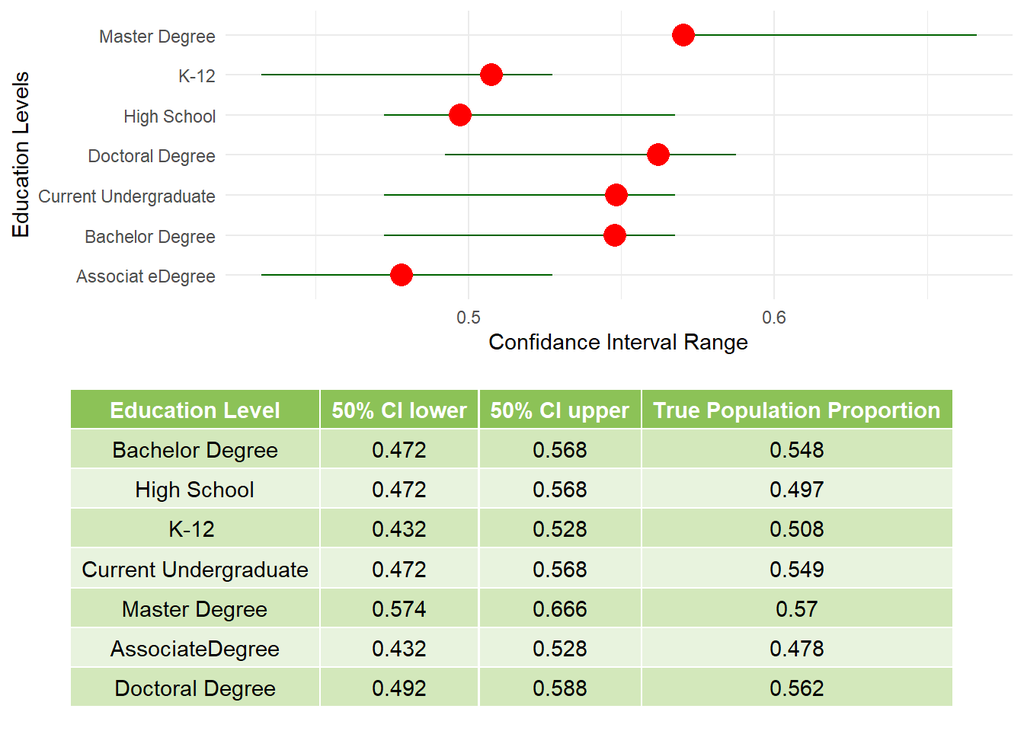

```r
ggarrange(chart50,table50,
          nrow=2,
          heights = c(2, 2))+
  ggtitle("50% Confidence Interval")
```

## 95% Confidence Interval of Democratic Affiliation

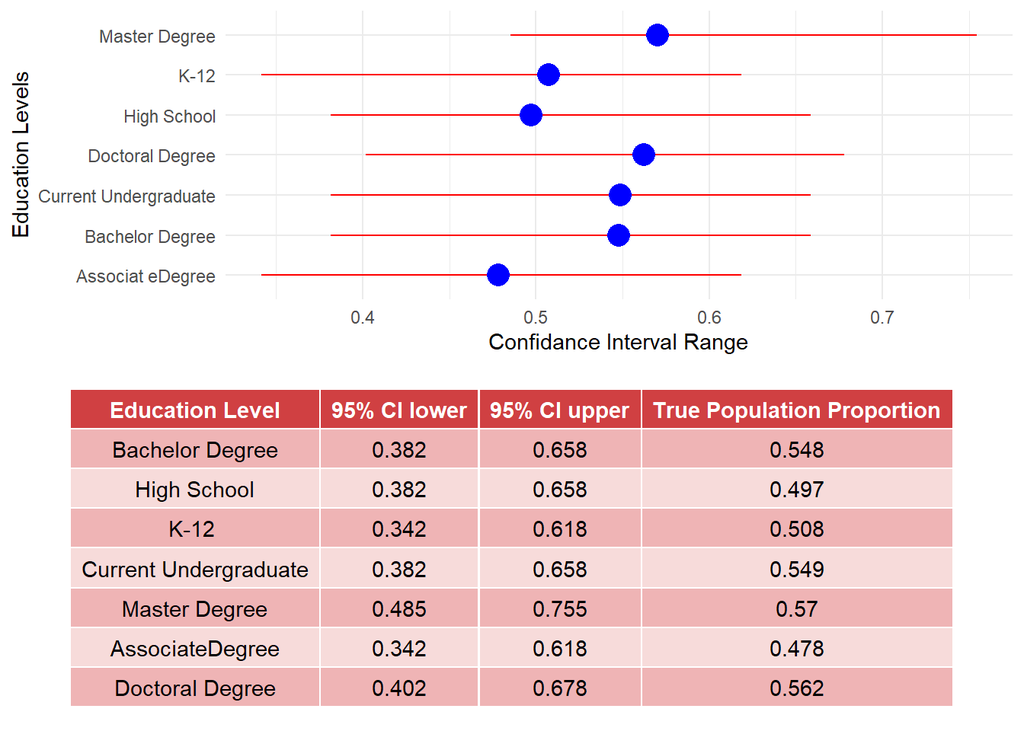

```r
ggarrange(chart95,table95,
          nrow=2,
          heights = c(2, 2))+
  ggtitle("95% Confidence Interval")
```

## 99% Confidence Interval of Democratic Affiliation

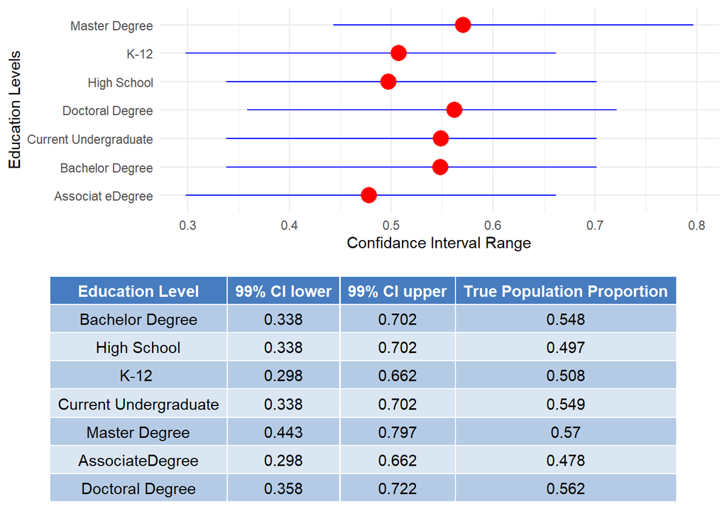

```r
ggarrange(Chart99,table99,
          nrow=2,
          heights = c(2, 2))+
  ggtitle("99% Confidence Interval")
```

**Interpretation:** The 99% Confidence iterval encompasses the population quite well. This is of course because we are 99% confident that our population is actually within the range. The population value is not close to the edges but rather in the center for most of the Education Level variables. However the downside to this is that the ranges are quite large. There are always trade offs to each of the different kinds of CI but we can see that we can accuratly encompass the true population within the Confidence Interval which is what we are trying to do. The difference between 50% and 95% was drastic as there is a larger difference, yet the difference between 95% and 99% was not so great.